# CW_NN (1)

## 1. Introduction

This is an introduction to Convolutional Neural Networks using TensorFlow 2.x Keras API. The dataset that we will work with is the Cifar10 dataset, a dataset of images from 10 different classes, and we will use two Sequential CNN with different architectures to identify the class of an image, and compare between the models.

### Installation Commands

First steps: Commands to install on startup of a new kernel.

```python
pip install tensorflow
```

```python
pip install pandas
```

```python
pip install seaborn
```

```python
pip install matplotlib
```

### Import foundation libraries

```python
import tensorflow as tf
import seaborn as sns
import numpy as np
import pandas as pd
import matplotlib.pyplot as plt
import matplotlib.image as mpimg
import itertools

print("TensorFlow version:", tf.__version__)
```

```
TensorFlow version: 2.11.1
```

### Import libraries for the model

```python
from tensorflow.keras.datasets import cifar10
from tensorflow.keras.preprocessing.image import ImageDataGenerator
from tensorflow.keras.models import Sequential
from tensorflow.keras.layers import Dense, Dropout, Activation, Flatten
from tensorflow.keras.layers import Conv2D, MaxPooling2D
```

## 2. Data Preprocessing

### Import the dataset

`x_train` is the dataset of 32x32 color images of objects that the model will be trained on.

`y_train` is the dataset of labels that correspond to `x_train`.

`x_test` is the dataset of 32x32 color images of objects that the model will be tested on.

`y_test` is the dataset of labels that correspond to `x_test`.

```python
cifar10 = tf.keras.datasets.cifar10 #import dataset
(x_train, y_train), (x_test, y_test) = cifar10.load_data()
```

```python
y_train = y_train.flatten() #flatten data to convert to 1D image vectors
y_test = y_test.flatten()
```

### How many images are in each class

[figure not shown]

```python
classes = ['airplane', 'automobile', 'bird', 'cat', 'deer', 'dog', 'frog', 'horse', 'ship', 'truck']

plt.figure(figsize=(10,7)) #plot all the classes
p = sns.countplot(y_train)
```

### Check for NaN values in our data

```python
np.isnan(x_train).any()
```

```
False
```

```python
np.isnan(x_test).any()
```

```
False
```

### Normalize and Reshape data

```python
input_shape = (32, 32, 3)

#reshaped t0 4D
#we want each value to be between 0.0 and 1.0. As all values originally fall under the 0.0-255.0 range, divide by 255.0.
x_train = x_train.reshape(x_train.shape[0], x_train.shape[1], x_train.shape[2], 3)
x_train = x_train / 255.0

x_test = x_test.reshape(x_test.shape[0], x_test.shape[1], x_test.shape[2], 3)
x_test = x_test / 255.0
```

### Label encoding

```python
#convert to one-hot encodings, to include categorical dataset in our model
y_train = tf.one_hot(y_train.astype(np.int32), depth=10)
y_test = tf.one_hot(y_test.astype(np.int32), depth=10)
```

```python
y_train[0]
```

```
<tf.Tensor: shape=(10,), dtype=float32, numpy=array([0., 0., 0., 0., 0., 0., 1., 0., 0., 0.], dtype=float32)>
```

### Visualize data

```
tf.Tensor([0. 0. 0. 0. 0. 0. 0. 0. 0. 1.], shape=(10,), dtype=float32)
```

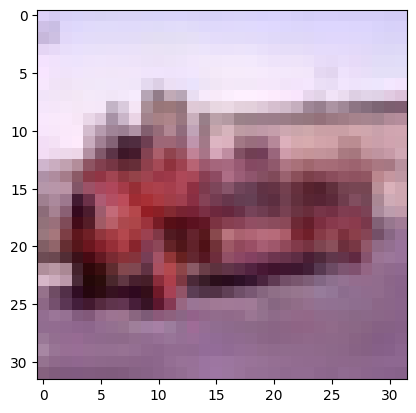

```python
plt.imshow(x_train[67])
print(y_train[67])
```

## 3. CNN

### 3.1 Define the model (1st)

#### Basic CNN structure is as follows: *Conv-Conv-Pool-Drop-Conv-Conv-Pool-Drop*

> The following cell defines `batch_size`, `num_classes`, and `epochs`.

```python
#Initialize variables
batch_size = 32
num_classes = 10
epochs = 50
```

```python
model_1 = tf.keras.models.Sequential([
    tf.keras.layers.Conv2D(32, 3, padding='same', input_shape=x_train.shape[1:], activation='relu'),
    tf.keras.layers.Conv2D(32, 3, activation='relu'), #relu is the rectifier, and it is used to find nonlinearity in the data.
    tf.keras.layers.MaxPooling2D(), #MaxPool2D is a downsampling filter.
    tf.keras.layers.Dropout(0.25),  #Regularization Layer with 25% dropout

    tf.keras.layers.Conv2D(64, 3, padding='same', activation='relu'),
    tf.keras.layers.Conv2D(64, 3, activation='relu'),
    tf.keras.layers.MaxPooling2D(),
    tf.keras.layers.Dropout(0.25),

    tf.keras.layers.Flatten(),  #Converts tensors into 1D vectors
    tf.keras.layers.Dense(512, activation='relu'),
    tf.keras.layers.Dropout(0.5),
    tf.keras.layers.Dense(num_classes, activation='softmax'),
])

# Customizable Parameters
model_1.compile(optimizer=tf.keras.optimizers.legacy.RMSprop(learning_rate=0.0001, decay=1e-06),
            loss='categorical_crossentropy', metrics=['acc'])
```

### 3.2 Display the Architecture of the Model

```python
model_1.summary() #Display Model Architecture
```

```
Model: "sequential"
_________________________________________________________________
 Layer (type)                Output Shape              Param #
=================================================================
 conv2d (Conv2D)             (None, 32, 32, 32)        896

 conv2d_1 (Conv2D)           (None, 30, 30, 32)        9248

 max_pooling2d (MaxPooling2D  (None, 15, 15, 32)       0
 )

 dropout (Dropout)           (None, 15, 15, 32)        0

 conv2d_2 (Conv2D)           (None, 15, 15, 64)        18496

 conv2d_3 (Conv2D)           (None, 13, 13, 64)        36928

 max_pooling2d_1 (MaxPooling  (None, 6, 6, 64)         0
 2D)

 dropout_1 (Dropout)         (None, 6, 6, 64)          0

 flatten (Flatten)           (None, 2304)              0

 dense (Dense)               (None, 512)               1180160

 dropout_2 (Dropout)         (None, 512)               0

 dense_1 (Dense)             (None, 10)                5130

=================================================================
Total params: 1,250,858
Trainable params: 1,250,858
Non-trainable params: 0
_________________________________________________________________
```

### 3.3 Fit the training data

```python
#Fit the model
history_1 = model_1.fit(x_train, y_train, validation_data = (x_test, y_test), batch_size = batch_size, epochs = epochs)
```

## 4. Evaluate the Model, and Change the Parameters

### 4.1 Loss and Accuracy Curves

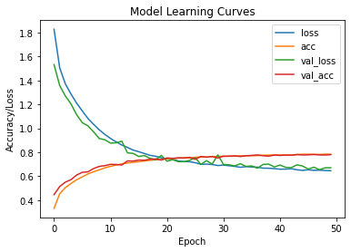

```python
#Plot Learning curves for the model
history_df_1 = pd.DataFrame(history_1.history)

fig, ax = plt.subplots()
history_df_1.plot(ax=ax)
ax.set(title='Model Learning Curves', xlabel='Epoch', ylabel='Accuracy/Loss')
plt.show()
```

### 4.2 Predict Results

```python
#Predict Results
test_loss, test_acc = model_1.evaluate(x_test, y_test)
```

> Our model runs with an accuracy of **78%** on our testing data

### 4.3 Confusion Matrix

```python
# Predict the values from the validation dataset
y_pred = model_1.predict(x_test)
# Convert predictions classes to one hot vectors
y_pred_classes = np.argmax(y_pred, axis = 1)
# Convert validation observations to one hot vectors
y_true = np.argmax(y_test, axis = 1)
# Compute the confusion matrix
confusion_matrix_1 = tf.math.confusion_matrix(y_true, y_pred_classes)
```

```
[[Text(0.5, 0, 'airplane'),
 [Text(0, 0.5, 'airplane'),
```

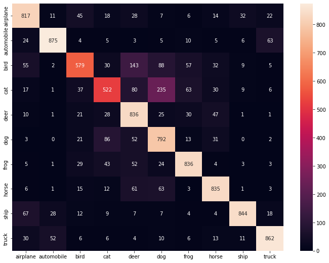

```python
#Plot results
plt.figure(figsize=(12,9))
a = sns.heatmap(confusion_matrix_1, annot = True, fmt = 'g')
a.set(xticklabels = classes, yticklabels = classes)
```

We see that our model classifies automobiles quite well, with **875** out of **1000** automobile images being classified correctly. In addition to, we see a relatively high confusion between cats and dogs.

### End of Source [1]

### 4.4 Define the 1st Model with changed Parameters

Repeat steps 3 and 4 to 4.3. The following cell defines `batch_size_scnd`, `num_classes`, and `epochs_scnd`.

#### 4.4.1 Add Momentum and Sigmoid Activation:

> **Changed Parameters:**
1. Increased batch size from 32 to 128
2. Reduce number of epochs from 50 to 25
3. Changed final activation function: `Softmax` to `Sigmoid`
4. Added `momentum` in `model.compile`
5. Increased `learning rate` to 0.0005

```python
#Initialize variables
batch_size_scnd = 128
num_classes = 10
epochs_scnd = 25
```

```python
# Neural Architecture
model_12 = tf.keras.models.Sequential([
    tf.keras.layers.Conv2D(32, 3, padding='same', input_shape=x_train.shape[1:], activation='relu'),
    tf.keras.layers.Conv2D(32, 3, activation='relu'),
    tf.keras.layers.MaxPooling2D(),
    tf.keras.layers.Dropout(0.25),

    tf.keras.layers.Conv2D(64, 3, padding='same', activation='relu'),
    tf.keras.layers.Conv2D(64, 3, activation='relu'),
    tf.keras.layers.MaxPooling2D(),
    tf.keras.layers.Dropout(0.25),

    tf.keras.layers.Flatten(), # Convert the vectors to 1D image
    tf.keras.layers.Dense(512, activation='relu'),
    tf.keras.layers.Dropout(0.5),
    tf.keras.layers.Dense(num_classes, activation='sigmoid'),
])

# Customizable Parameters
model_12.compile(optimizer=tf.keras.optimizers.legacy.RMSprop(learning_rate=0.0005, momentum=0.9, decay=1e-06),
            loss='categorical_crossentropy', metrics=['acc'])

#Fit the model
history_12 = model_12.fit(x_train, y_train, validation_data = (x_test, y_test), batch_size = batch_size_scnd, epochs = epochs_scnd)
```

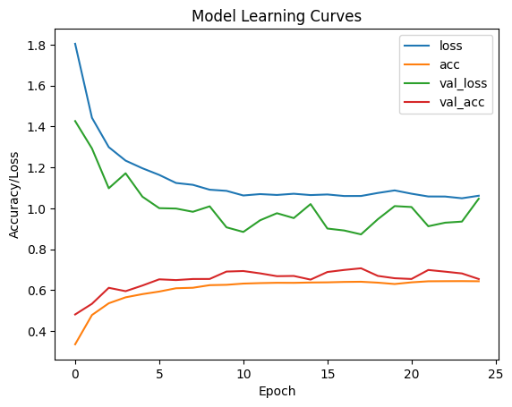

```python
#Plot Learning curves for the model
history_df_12 = pd.DataFrame(history_12.history)

fig, ax = plt.subplots()
history_df_12.plot(ax=ax)
ax.set(title='Model Learning Curves', xlabel='Epoch', ylabel='Accuracy/Loss')
plt.show()
```

```python
#Predict Results
test_loss, test_acc = model_12.evaluate(x_test, y_test)
```

> Our model runs with an accuracy of **65%** on our testing data

```
[[Text(0.5, 0, 'airplane'),
 [Text(0, 0.5, 'airplane'),
```

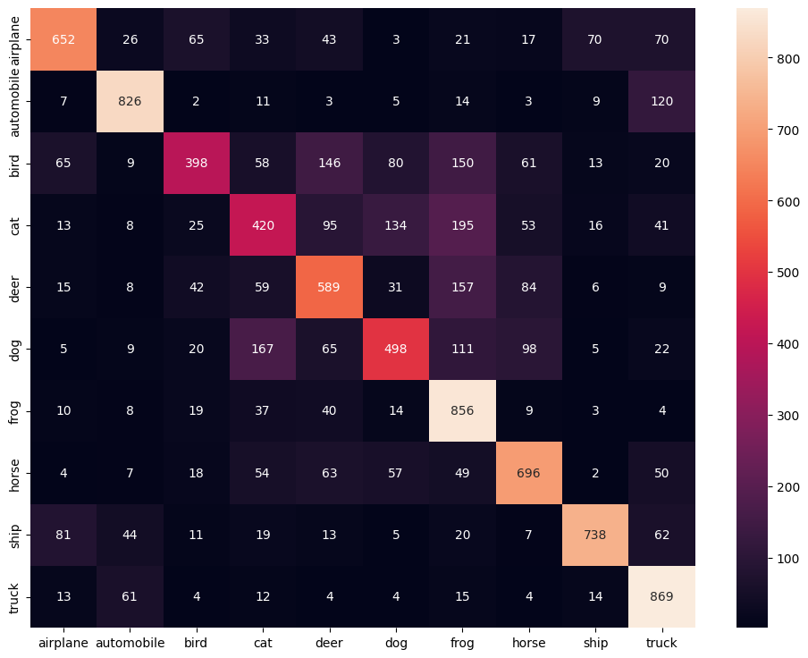

```python
# Predict the values from the validation dataset
y_pred = model_12.predict(x_test)
# Convert predictions classes to one hot vectors
y_pred_classes = np.argmax(y_pred, axis = 1)
# Convert validation observations to one hot vectors
y_true = np.argmax(y_test, axis = 1)
# Compute the confusion matrix
confusion_matrix_12 = tf.math.confusion_matrix(y_true, y_pred_classes)

#Plot results
plt.figure(figsize=(12,9))
a = sns.heatmap(confusion_matrix_12, annot = True, fmt = 'g')
a.set(xticklabels = classes, yticklabels = classes)
```

> We see that our model now correctly classifies trucks better than automobiles, with **869** out of **1000** truck images. Moreover, now we see a relatively **higher** confusion between several classes, justifying the lower accuracy of this model.

#### 4.4.2 Increase Batch Size, Reduce Epoch:

> **Changed Parameters:**
1. Increased batch size from 128 to 2048
2. Reduce number of epochs from 25 to 10 due to time resources

```python
#Initialize variables
batch_size_scnd = 2048
num_classes = 10
epochs_scnd = 10

# Neural Architecture
model_13 = tf.keras.models.Sequential([
    tf.keras.layers.Conv2D(32, 3, padding='same', input_shape=x_train.shape[1:], activation='relu'),
    tf.keras.layers.Conv2D(32, 3, activation='relu'),
    tf.keras.layers.MaxPooling2D(),
    tf.keras.layers.Dropout(0.25),

    tf.keras.layers.Conv2D(64, 3, padding='same', activation='relu'),
    tf.keras.layers.Conv2D(64, 3, activation='relu'),
    tf.keras.layers.MaxPooling2D(),
    tf.keras.layers.Dropout(0.25),

    tf.keras.layers.Flatten(), # Convert the vectors to 1D image
    tf.keras.layers.Dense(512, activation='relu'),
    tf.keras.layers.Dropout(0.5),
    tf.keras.layers.Dense(num_classes, activation='sigmoid'),
])

# Customizable Parameters
model_13.compile(optimizer=tf.keras.optimizers.legacy.RMSprop(learning_rate=0.0005, momentum=0.9, decay=1e-06),
            loss='categorical_crossentropy', metrics=['acc'])

#Fit the model
history_13 = model_13.fit(x_train, y_train, validation_data = (x_test, y_test), batch_size = batch_size_scnd, epochs = epochs_scnd)
```

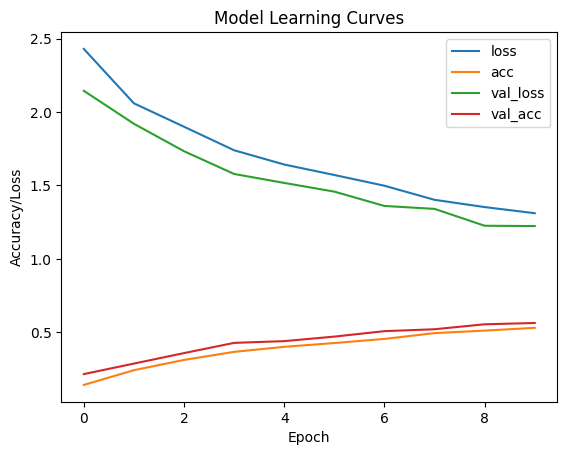

```python
#Plot Learning curves for the model
history_df_13 = pd.DataFrame(history_13.history)

fig, ax = plt.subplots()
history_df_13.plot(ax=ax)
ax.set(title='Model Learning Curves', xlabel='Epoch', ylabel='Accuracy/Loss')
plt.show()
```

```python
#Predict Results
test_loss, test_acc = model_13.evaluate(x_test, y_test)
```

> Our model runs with an accuracy of **56%** on our testing data

> We can also see the time for each Epoch to train has **reduced** due to the higher batch size.

```
[[Text(0.5, 0, 'airplane'),
 [Text(0, 0.5, 'airplane'),
```

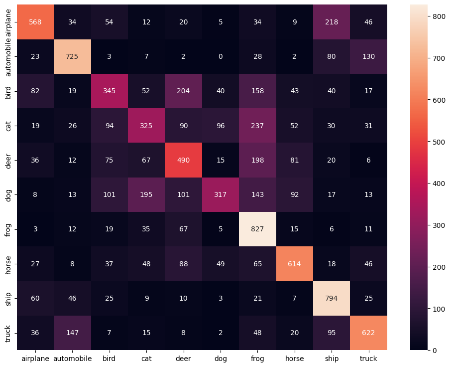

```python
# Predict the values from the validation dataset
y_pred = model_13.predict(x_test)
# Convert predictions classes to one hot vectors
y_pred_classes = np.argmax(y_pred, axis = 1)
# Convert validation observations to one hot vectors
y_true = np.argmax(y_test, axis = 1)
# Compute the confusion matrix
confusion_matrix_13 = tf.math.confusion_matrix(y_true, y_pred_classes)

#Plot results
plt.figure(figsize=(12,9))
a = sns.heatmap(confusion_matrix_13, annot = True, fmt = 'g')
a.set(xticklabels = classes, yticklabels = classes)
```

> Our model has dropped in accuracy due to the large batch size used, with most of the classes being confused for other classes. The heatmap shows more red coloured pixels, indicating that the model struggles to classify images correctly. This may also be due to a low number of Epochs used to train the model; Therefore, it could have had more potential to improve.

#### 4.4.3 Optimizer: Adam

> **Changed Parameters:**
1. Changed Optimizer: `RSMprop` to `Adam`

```python
#Initialize variables
batch_size_scnd = 2048
num_classes = 10
epochs_scnd = 10

# Neural Architecture
model_14 = tf.keras.models.Sequential([
    tf.keras.layers.Conv2D(32, 3, padding='same', input_shape=x_train.shape[1:], activation='relu'),
    tf.keras.layers.Conv2D(32, 3, activation='relu'),
    tf.keras.layers.MaxPooling2D(),
    tf.keras.layers.Dropout(0.25),

    tf.keras.layers.Conv2D(64, 3, padding='same', activation='relu'),
    tf.keras.layers.Conv2D(64, 3, activation='relu'),
    tf.keras.layers.MaxPooling2D(),
    tf.keras.layers.Dropout(0.25),

    tf.keras.layers.Flatten(), # Convert the vectors to 1D image
    tf.keras.layers.Dense(512, activation='relu'),
    tf.keras.layers.Dropout(0.5),
    tf.keras.layers.Dense(num_classes, activation='sigmoid'),
])

# Customizable Parameters
model_14.compile(optimizer=tf.keras.optimizers.legacy.Adam(learning_rate=0.0005, decay=1e-06),
            loss='categorical_crossentropy', metrics=['acc'])

#Fit the model
history_14 = model_14.fit(x_train, y_train, validation_data = (x_test, y_test), batch_size = batch_size_scnd, epochs = epochs_scnd)
```

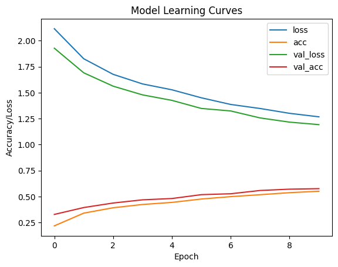

```python
#Plot Learning curves for the model
history_df_14 = pd.DataFrame(history_14.history)

fig, ax = plt.subplots()
history_df_14.plot(ax=ax)
ax.set(title='Model Learning Curves', xlabel='Epoch', ylabel='Accuracy/Loss')
plt.show()
```

```python
#Predict Results
test_loss, test_acc = model_14.evaluate(x_test, y_test)
```

> Our model runs with an accuracy of **57%** on our testing data

```
[[Text(0.5, 0, 'airplane'),
 [Text(0, 0.5, 'airplane'),
```

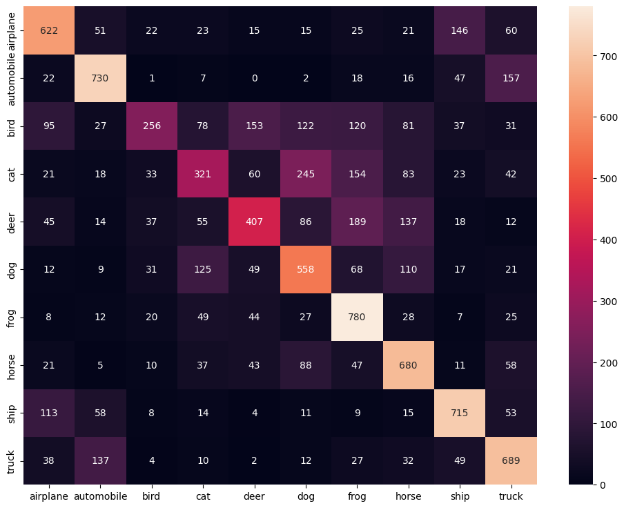

```python
# Predict the values from the validation dataset
y_pred = model_14.predict(x_test)
# Convert predictions classes to one hot vectors
y_pred_classes = np.argmax(y_pred, axis = 1)
# Convert validation observations to one hot vectors
y_true = np.argmax(y_test, axis = 1)
# Compute the confusion matrix
confusion_matrix_14 = tf.math.confusion_matrix(y_true, y_pred_classes)

#Plot results
plt.figure(figsize=(12,9))
a = sns.heatmap(confusion_matrix_14, annot = True, fmt = 'g')
a.set(xticklabels = classes, yticklabels = classes)
```

> Error classification is more spread out now, however in this model there is high confusion between cats and dogs. The heatmap shows a more scattered variation of red pixels, indicating that the model struggles to classify a wider range of images correctly, but less often than previously which is an improvement.

#### 4.4.4 Increase Learning Rate:

> **Changed Parameters:**
1. Increased Learning Rate: `0.0005` to `0.001`

```python
#Initialize variables
batch_size_scnd = 2048
num_classes = 10
epochs_scnd = 10

# Neural Architecture
model_15 = tf.keras.models.Sequential([
    tf.keras.layers.Conv2D(32, 3, padding='same', input_shape=x_train.shape[1:], activation='relu'),
    tf.keras.layers.Conv2D(32, 3, activation='relu'),
    tf.keras.layers.MaxPooling2D(),
    tf.keras.layers.Dropout(0.25),

    tf.keras.layers.Conv2D(64, 3, padding='same', activation='relu'),
    tf.keras.layers.Conv2D(64, 3, activation='relu'),
    tf.keras.layers.MaxPooling2D(),
    tf.keras.layers.Dropout(0.25),

    tf.keras.layers.Flatten(), # Convert the vectors to 1D image
    tf.keras.layers.Dense(512, activation='relu'),
    tf.keras.layers.Dropout(0.5),
    tf.keras.layers.Dense(num_classes, activation='sigmoid'),
])

# Customizable Parameters
model_15.compile(optimizer=tf.keras.optimizers.legacy.Adam(learning_rate=0.001, decay=1e-06),
            loss='categorical_crossentropy', metrics=['acc'])

#Fit the model
history_15 = model_15.fit(x_train, y_train, validation_data = (x_test, y_test), batch_size = batch_size_scnd, epochs = epochs_scnd)
```

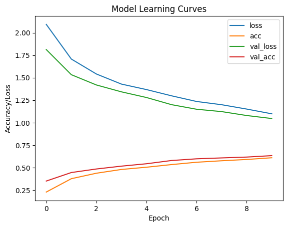

```python
#Plot Learning curves for the model
history_df_15 = pd.DataFrame(history_15.history)

fig, ax = plt.subplots()
history_df_15.plot(ax=ax)
ax.set(title='Model Learning Curves', xlabel='Epoch', ylabel='Accuracy/Loss')
plt.show()
```

```python
#Predict Results
test_loss, test_acc = model_15.evaluate(x_test, y_test)
```

> Our model runs with an accuracy of **63%** on our testing data. With just 10 epochs of training the model, it reaches a solid performance.

> From the graph we can realize that there is a smoother gradient for val_loss compared to the previous 2 models. The model seems to converge to a specific point without overtraining so far.

```
[[Text(0.5, 0, 'airplane'),
 [Text(0, 0.5, 'airplane'),
```

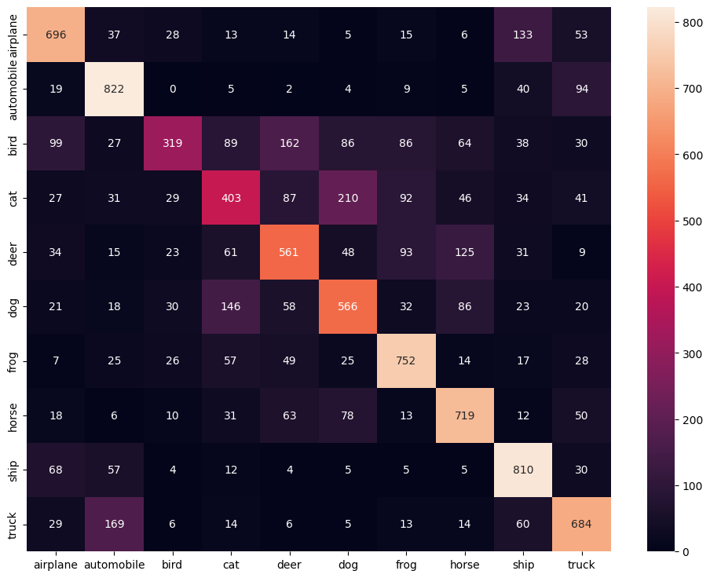

```python
# Predict the values from the validation dataset
y_pred = model_15.predict(x_test)
# Convert predictions classes to one hot vectors
y_pred_classes = np.argmax(y_pred, axis = 1)
# Convert validation observations to one hot vectors
y_true = np.argmax(y_test, axis = 1)
# Compute the confusion matrix
confusion_matrix_15 = tf.math.confusion_matrix(y_true, y_pred_classes)

#Plot results
plt.figure(figsize=(12,9))
a = sns.heatmap(confusion_matrix_15, annot = True, fmt = 'g')
a.set(xticklabels = classes, yticklabels = classes)
```

> In this model there still remains a high confusion between cats and dogs, and it appears that this is an outlier so far. There are now more classifications with a higher colour graident, indicating that the model overall has improved.

#### 4.4.5 Reduce Batch Size:

> **Changed Parameters:**
1. Reduced Batch Size: `2048` to `128`

```python
#Initialize variables
batch_size_scnd = 128
num_classes = 10
epochs_scnd = 10

# Neural Architecture
model_16 = tf.keras.models.Sequential([
    tf.keras.layers.Conv2D(32, 3, padding='same', input_shape=x_train.shape[1:], activation='relu'),
    tf.keras.layers.Conv2D(32, 3, activation='relu'),
    tf.keras.layers.MaxPooling2D(),
    tf.keras.layers.Dropout(0.25),

    tf.keras.layers.Conv2D(64, 3, padding='same', activation='relu'),
    tf.keras.layers.Conv2D(64, 3, activation='relu'),
    tf.keras.layers.MaxPooling2D(),
    tf.keras.layers.Dropout(0.25),

    tf.keras.layers.Flatten(), # Convert the vectors to 1D image
    tf.keras.layers.Dense(512, activation='relu'),
    tf.keras.layers.Dropout(0.5),
    tf.keras.layers.Dense(num_classes, activation='sigmoid'),
])

# Customizable Parameters
model_16.compile(optimizer=tf.keras.optimizers.legacy.Adam(learning_rate=0.001, decay=1e-06),
            loss='categorical_crossentropy', metrics=['acc'])

#Fit the model
history_16 = model_16.fit(x_train, y_train, validation_data = (x_test, y_test), batch_size = batch_size_scnd, epochs = epochs_scnd)
```

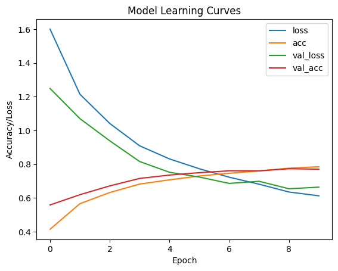

```python
#Plot Learning curves for the model
history_df_16 = pd.DataFrame(history_16.history)

fig, ax = plt.subplots()
history_df_16.plot(ax=ax)
ax.set(title='Model Learning Curves', xlabel='Epoch', ylabel='Accuracy/Loss')
plt.show()
```

```python
#Predict Results
test_loss, test_acc = model_16.evaluate(x_test, y_test)
```

> Our model runs with an accuracy of **77%** on our testing data. With just 10 epochs of training the model, it reaches a solid performance. This also proves that a lower batch size is more reliable.

> The learning curves intersect at around the 5th Epoch, and there isn't much difference between both accuracy curves and loss curves after 8 Epochs.

```
[[Text(0.5, 0, 'airplane'),
 [Text(0, 0.5, 'airplane'),
```

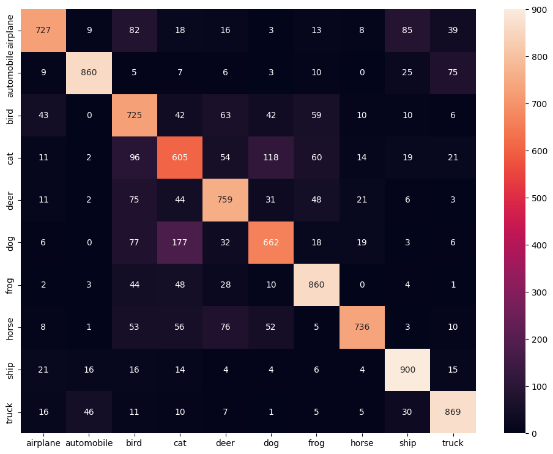

```python
# Predict the values from the validation dataset
y_pred = model_16.predict(x_test)
# Convert predictions classes to one hot vectors
y_pred_classes = np.argmax(y_pred, axis = 1)
# Convert validation observations to one hot vectors
y_true = np.argmax(y_test, axis = 1)
# Compute the confusion matrix
confusion_matrix_16 = tf.math.confusion_matrix(y_true, y_pred_classes)

#Plot results
plt.figure(figsize=(12,9))
a = sns.heatmap(confusion_matrix_16, annot = True, fmt = 'g')
a.set(xticklabels = classes, yticklabels = classes)
```

> Most images are correctly being classified as it shows in the heatmap that most common pixels have a high colour gradient.

## 5. CNN (2nd)

### 5.1 Define the model (2nd)

#### Basic CNN structure is as follows: *Conv-Pool-Conv-Pool-Conv-Pool-Conv-Pool* with doubling the number of filters every stage

> The following cell defines `batch_size`, `num_classes`, and `epochs`.

```python
#Initialize variables
batch_size = 128
num_classes = 10
epochs = 25
```

```python
model_2 = tf.keras.models.Sequential([
    tf.keras.layers.Conv2D(32, kernel_size=(3, 3), padding='same', input_shape=x_train.shape[1:], activation='relu'),
    tf.keras.layers.MaxPooling2D(pool_size=(2, 2),strides=2),

    tf.keras.layers.Conv2D(64, kernel_size=(3, 3), padding='same', activation='relu'),
    tf.keras.layers.MaxPooling2D(pool_size=(2, 2),strides=2),

    tf.keras.layers.Conv2D(128, kernel_size=(3, 3), padding='same', activation='relu'),
    tf.keras.layers.MaxPooling2D(pool_size=(2, 2),strides=2),

    tf.keras.layers.Conv2D(256, kernel_size=(3, 3), padding='same', activation='relu'),
    tf.keras.layers.MaxPooling2D(pool_size=(2, 2),strides=2),

    tf.keras.layers.Flatten(),
    tf.keras.layers.Dense(64, activation='relu'),
    tf.keras.layers.Dense(num_classes, activation='softmax'),
])

# Customizable Parameters
model_2.compile(optimizer=tf.keras.optimizers.legacy.RMSprop(learning_rate=0.0005, momentum = 0.9, decay=1e-06),
            loss='categorical_crossentropy', metrics=['acc'])
```

### 5.2 Display the Architecture of the Model

```python
model_2.summary() #Display Model Architecture
```

```
Model: "sequential_5"
_________________________________________________________________
 Layer (type)                Output Shape              Param #
=================================================================
 conv2d_20 (Conv2D)          (None, 32, 32, 32)        896

 max_pooling2d_10 (MaxPoolin  (None, 16, 16, 32)       0
 g2D)

 conv2d_21 (Conv2D)          (None, 16, 16, 64)        18496

 max_pooling2d_11 (MaxPoolin  (None, 8, 8, 64)         0
 g2D)

 conv2d_22 (Conv2D)          (None, 8, 8, 128)         73856

 max_pooling2d_12 (MaxPoolin  (None, 4, 4, 128)        0
 g2D)

 conv2d_23 (Conv2D)          (None, 4, 4, 256)         295168

 max_pooling2d_13 (MaxPoolin  (None, 2, 2, 256)        0
 g2D)

 flatten_5 (Flatten)         (None, 1024)              0

 dense_10 (Dense)            (None, 64)                65600

 dense_11 (Dense)            (None, 10)                650

=================================================================
Total params: 454,666
Trainable params: 454,666
Non-trainable params: 0
_________________________________________________________________
```

### 5.3 Fit the training data

```python
#Fit the model
history_2 = model_2.fit(x_train, y_train, validation_data = (x_test, y_test), batch_size = batch_size, epochs = epochs)
```

## 6. Evaluate the 2nd Model, and Change the Parameters

### 6.1 Loss and Accuracy Curves

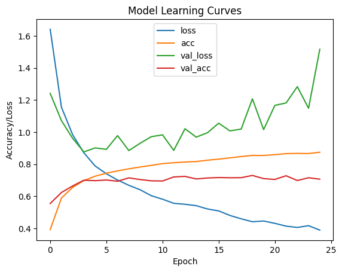

```python
#Plot Learning curves for the model
history_df_2 = pd.DataFrame(history_2.history)

fig, ax = plt.subplots()
history_df_2.plot(ax=ax)
ax.set(title='Model Learning Curves', xlabel='Epoch', ylabel='Accuracy/Loss')
plt.show()
```

### 6.2 Predict Results

```python
#Predict Results
test_loss, test_acc = model_2.evaluate(x_test, y_test)
```

> Our model runs with an accuracy of **70%** on our testing data

### 6.3 Confusion Matrix

```python
# Predict the values from the validation dataset
y_pred = model_2.predict(x_test)
# Convert predictions classes to one hot vectors
y_pred_classes = np.argmax(y_pred, axis = 1)
# Convert validation observations to one hot vectors
y_true = np.argmax(y_test, axis = 1)
# Compute the confusion matrix
confusion_matrix_2 = tf.math.confusion_matrix(y_true, y_pred_classes)
```

```
[[Text(0.5, 0, 'airplane'),
 [Text(0, 0.5, 'airplane'),
```

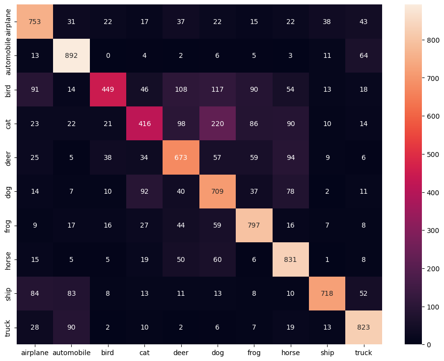

```python
#Plot results
plt.figure(figsize=(12,9))
a = sns.heatmap(confusion_matrix_2, annot = True, fmt = 'g')
a.set(xticklabels = classes, yticklabels = classes)
```

We see that our model classifies automobiles and trucks quite well, with over **800** out of **1000** automobile and truck images being classified correctly. In addition to, we see a relatively high confusion between cats and dogs, and vice versa.

### 6.4 Define the 2nd Model with changed Parameters

Repeat steps 3 and 4 to 4.3. The following cell defines `batch_size_scnd`, `num_classes`, and `epochs_scnd`.

#### 6.4.1 Optimizer: Adam

> **Changed Parameters:**
1. Changed Optimizer: `RMSprop` to `Adam`
2. Increased `learning rate` to 0.001
3. Reduced Epochs from 25 to 10

```python
#Initialize variables
batch_size_scnd = 128
num_classes = 10
epochs_scnd = 10
```

```python
model_21 = tf.keras.models.Sequential([
    tf.keras.layers.Conv2D(32, kernel_size=(3, 3), padding='same', input_shape=x_train.shape[1:], activation='relu'),
    tf.keras.layers.MaxPooling2D(pool_size=(2, 2),strides=2),

    tf.keras.layers.Conv2D(64, kernel_size=(3, 3), padding='same', activation='relu'),
    tf.keras.layers.MaxPooling2D(pool_size=(2, 2),strides=2),

    tf.keras.layers.Conv2D(128, kernel_size=(3, 3), padding='same', activation='relu'),
    tf.keras.layers.MaxPooling2D(pool_size=(2, 2),strides=2),

    tf.keras.layers.Conv2D(256, kernel_size=(3, 3), padding='same', activation='relu'),
    tf.keras.layers.MaxPooling2D(pool_size=(2, 2),strides=2),

    tf.keras.layers.Flatten(),
    tf.keras.layers.Dense(64, activation='relu'),
    tf.keras.layers.Dense(num_classes, activation='softmax'),
])

# Customizable Parameters
model_21.compile(optimizer=tf.keras.optimizers.legacy.Adam(learning_rate=0.001, decay=1e-06),
            loss='categorical_crossentropy', metrics=['acc'])

#Fit the model
history_21 = model_21.fit(x_train, y_train, validation_data = (x_test, y_test), batch_size = batch_size_scnd, epochs = epochs_scnd)
```

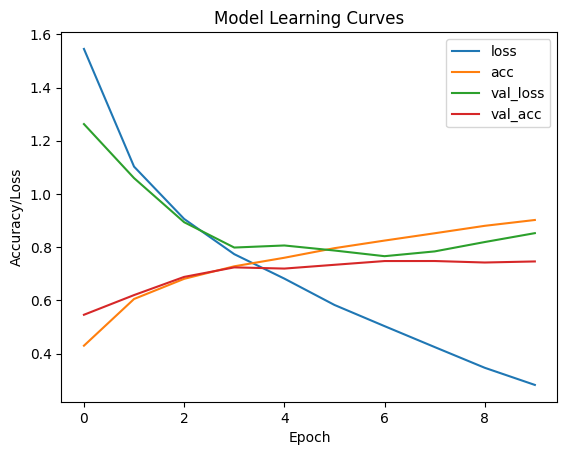

```python
#Plot Learning curves for the model
history_df_21 = pd.DataFrame(history_21.history)

fig, ax = plt.subplots()
history_df_21.plot(ax=ax)
ax.set(title='Model Learning Curves', xlabel='Epoch', ylabel='Accuracy/Loss')
plt.show()
```

```python
#Predict Results
test_loss, test_acc = model_21.evaluate(x_test, y_test)
```

> Our model runs with an accuracy of **75%** on our testing data

```
[[Text(0.5, 0, 'airplane'),
 [Text(0, 0.5, 'airplane'),
```

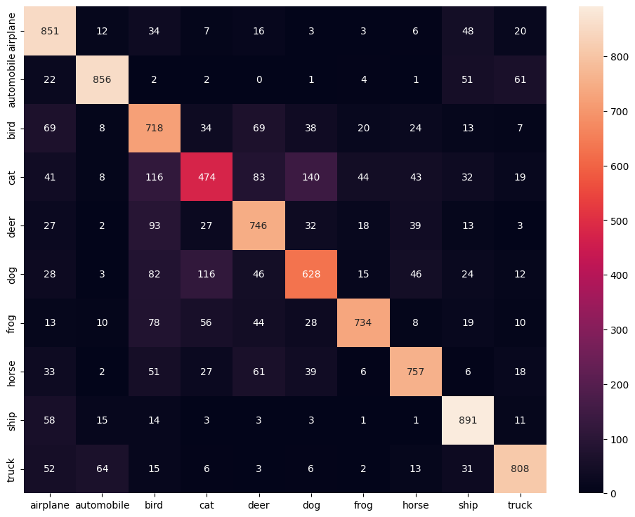

```python
# Predict the values from the validation dataset
y_pred = model_21.predict(x_test)
# Convert predictions classes to one hot vectors
y_pred_classes = np.argmax(y_pred, axis = 1)
# Convert validation observations to one hot vectors
y_true = np.argmax(y_test, axis = 1)
# Compute the confusion matrix
confusion_matrix_21 = tf.math.confusion_matrix(y_true, y_pred_classes)

#Plot results
plt.figure(figsize=(12,9))
a = sns.heatmap(confusion_matrix_21, annot = True, fmt = 'g')
a.set(xticklabels = classes, yticklabels = classes)
```

> We see that our model classifies ships pretty well, with over **800** out of **1000** ship images. Moreover, now we see the confusion between cats and dogs reduce, justifying the higher accuracy of this model compared to preious models.

#### 6.4.2 Include Dropout Layers:

> **Changed Parameters:**
1. Added Dropout Layers after each of the Pooling Layers with a rate of 25%

```python
#Initialize variables
batch_size_scnd = 128
num_classes = 10
epochs_scnd = 10

model_22 = tf.keras.models.Sequential([
    tf.keras.layers.Conv2D(32, kernel_size=(3, 3), padding='same', input_shape=x_train.shape[1:], activation='relu'),
    tf.keras.layers.MaxPooling2D(pool_size=(2, 2),strides=2),
    tf.keras.layers.Dropout(0.25),

    tf.keras.layers.Conv2D(64, kernel_size=(3, 3), padding='same', activation='relu'),
    tf.keras.layers.MaxPooling2D(pool_size=(2, 2),strides=2),
    tf.keras.layers.Dropout(0.25),

    tf.keras.layers.Conv2D(128, kernel_size=(3, 3), padding='same', activation='relu'),
    tf.keras.layers.MaxPooling2D(pool_size=(2, 2),strides=2),
    tf.keras.layers.Dropout(0.25),

    tf.keras.layers.Conv2D(256, kernel_size=(3, 3), padding='same', activation='relu'),
    tf.keras.layers.MaxPooling2D(pool_size=(2, 2),strides=2),
    tf.keras.layers.Dropout(0.25),

    tf.keras.layers.Flatten(),
    tf.keras.layers.Dense(64, activation='relu'),
    tf.keras.layers.Dense(num_classes, activation='softmax'),
])

# Customizable Parameters
model_22.compile(optimizer=tf.keras.optimizers.legacy.Adam(learning_rate=0.001, decay=1e-06),
            loss='categorical_crossentropy', metrics=['acc'])

#Fit the model
history_22 = model_22.fit(x_train, y_train, validation_data = (x_test, y_test), batch_size = batch_size_scnd, epochs = epochs_scnd)
```

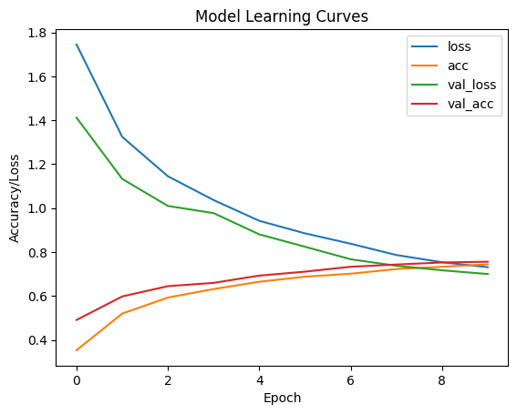

```python
#Plot Learning curves for the model
history_df_22 = pd.DataFrame(history_22.history)

fig, ax = plt.subplots()
history_df_22.plot(ax=ax)
ax.set(title='Model Learning Curves', xlabel='Epoch', ylabel='Accuracy/Loss')
plt.show()
```

```python
#Predict Results
test_loss, test_acc = model_22.evaluate(x_test, y_test)
```

> Our model runs with an accuracy of **76%** on our testing data.

There is an improvement of **1%** overall to the model after implementing dropout layers

```
[[Text(0.5, 0, 'airplane'),
 [Text(0, 0.5, 'airplane'),
```

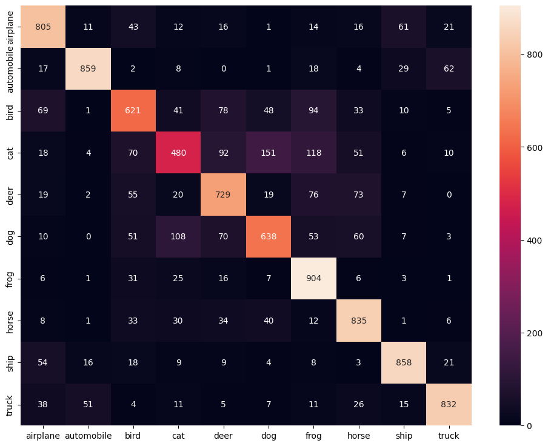

```python
# Predict the values from the validation dataset
y_pred = model_22.predict(x_test)
# Convert predictions classes to one hot vectors
y_pred_classes = np.argmax(y_pred, axis = 1)
# Convert validation observations to one hot vectors
y_true = np.argmax(y_test, axis = 1)
# Compute the confusion matrix
confusion_matrix_22 = tf.math.confusion_matrix(y_true, y_pred_classes)

#Plot results
plt.figure(figsize=(12,9))
a = sns.heatmap(confusion_matrix_22, annot = True, fmt = 'g')
a.set(xticklabels = classes, yticklabels = classes)
```

> We see that our model classifies frogs pretty well, with **904** out of **1000** frog images.

#### 6.4.3 Batch Normalization:

> **Changed Parameters:**
1. Added Batch Normalization after each Dropout Layer

```python
#Initialize variables
batch_size_scnd = 128
num_classes = 10
epochs_scnd = 10

model_23 = tf.keras.models.Sequential([
    tf.keras.layers.Conv2D(32, kernel_size=(3, 3), padding='same', input_shape=x_train.shape[1:], activation='relu'),
    tf.keras.layers.MaxPooling2D(pool_size=(2, 2),strides=2),
    tf.keras.layers.Dropout(0.25),
    tf.keras.layers.BatchNormalization(),

    tf.keras.layers.Conv2D(64, kernel_size=(3, 3), padding='same', activation='relu'),
    tf.keras.layers.MaxPooling2D(pool_size=(2, 2),strides=2),
    tf.keras.layers.Dropout(0.25),
    tf.keras.layers.BatchNormalization(),

    tf.keras.layers.Conv2D(128, kernel_size=(3, 3), padding='same', activation='relu'),
    tf.keras.layers.MaxPooling2D(pool_size=(2, 2),strides=2),
    tf.keras.layers.Dropout(0.25),
    tf.keras.layers.BatchNormalization(),

    tf.keras.layers.Conv2D(256, kernel_size=(3, 3), padding='same', activation='relu'),
    tf.keras.layers.MaxPooling2D(pool_size=(2, 2),strides=2),
    tf.keras.layers.Dropout(0.25),
    tf.keras.layers.BatchNormalization(),

    tf.keras.layers.Flatten(),
    tf.keras.layers.Dense(64, activation='relu'),
    tf.keras.layers.Dense(num_classes, activation='softmax'),
])

# Customizable Parameters
model_23.compile(optimizer=tf.keras.optimizers.legacy.Adam(learning_rate=0.001, decay=1e-06),
            loss='categorical_crossentropy', metrics=['acc'])

#Fit the model
history_23 = model_23.fit(x_train, y_train, validation_data = (x_test, y_test), batch_size = batch_size_scnd, epochs = epochs_scnd)
```

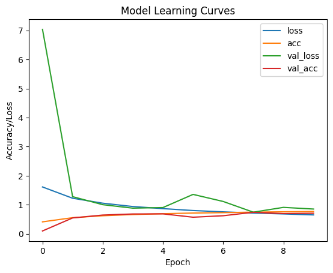

```python
#Plot Learning curves for the model
history_df_23 = pd.DataFrame(history_23.history)

fig, ax = plt.subplots()
history_df_23.plot(ax=ax)
ax.set(title='Model Learning Curves', xlabel='Epoch', ylabel='Accuracy/Loss')
plt.show()
```

```python
#Predict Results
test_loss, test_acc = model_23.evaluate(x_test, y_test)
```

> Our model runs with an accuracy of **70%** on our testing data.

> The learning curves (`loss`, `acc`) indicate that little errors occur on a lot of data.

```
[[Text(0.5, 0, 'airplane'),
 [Text(0, 0.5, 'airplane'),
```

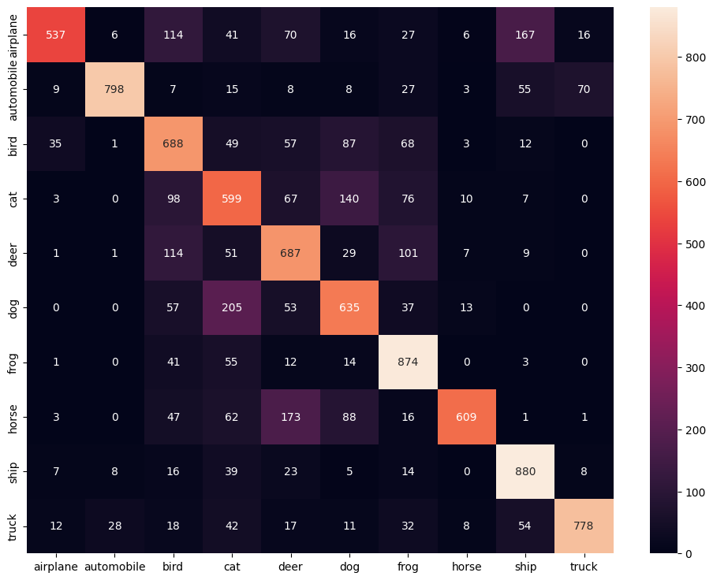

```python
# Predict the values from the validation dataset
y_pred = model_23.predict(x_test)
# Convert predictions classes to one hot vectors
y_pred_classes = np.argmax(y_pred, axis = 1)
# Convert validation observations to one hot vectors
y_true = np.argmax(y_test, axis = 1)
# Compute the confusion matrix
confusion_matrix_23 = tf.math.confusion_matrix(y_true, y_pred_classes)

#Plot results
plt.figure(figsize=(12,9))
a = sns.heatmap(confusion_matrix_23, annot = True, fmt = 'g')
a.set(xticklabels = classes, yticklabels = classes)
```

> We see that our model classifies ships better than frogs. Moreover, now we see more variation in red coloured pixels.

#### 6.4.4 Doubled Batch Size:

> **Changed Parameters:**
1. Doubled Batch size from 128 to 256

```python
#Initialize variables
batch_size_scnd = 256
num_classes = 10
epochs_scnd = 10

model_24 = tf.keras.models.Sequential([
    tf.keras.layers.Conv2D(32, kernel_size=(3, 3), padding='same', input_shape=x_train.shape[1:], activation='relu'),
    tf.keras.layers.MaxPooling2D(pool_size=(2, 2),strides=2),
    tf.keras.layers.Dropout(0.25),
    tf.keras.layers.BatchNormalization(),

    tf.keras.layers.Conv2D(64, kernel_size=(3, 3), padding='same', activation='relu'),
    tf.keras.layers.MaxPooling2D(pool_size=(2, 2),strides=2),
    tf.keras.layers.Dropout(0.25),
    tf.keras.layers.BatchNormalization(),

    tf.keras.layers.Conv2D(128, kernel_size=(3, 3), padding='same', activation='relu'),
    tf.keras.layers.MaxPooling2D(pool_size=(2, 2),strides=2),
    tf.keras.layers.Dropout(0.25),
    tf.keras.layers.BatchNormalization(),

    tf.keras.layers.Conv2D(256, kernel_size=(3, 3), padding='same', activation='relu'),
    tf.keras.layers.MaxPooling2D(pool_size=(2, 2),strides=2),
    tf.keras.layers.Dropout(0.25),
    tf.keras.layers.BatchNormalization(),

    tf.keras.layers.Flatten(),
    tf.keras.layers.Dense(64, activation='relu'),
    tf.keras.layers.Dense(num_classes, activation='softmax'),
])

# Customizable Parameters
model_24.compile(optimizer=tf.keras.optimizers.legacy.Adam(learning_rate=0.001, decay=1e-06),
            loss='categorical_crossentropy', metrics=['acc'])

#Fit the model
history_24 = model_24.fit(x_train, y_train, validation_data = (x_test, y_test), batch_size = batch_size_scnd, epochs = epochs_scnd)
```

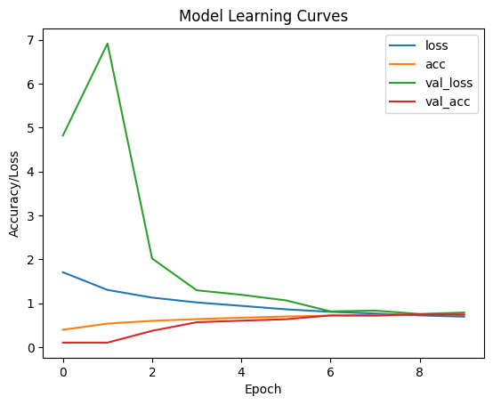

```python
#Plot Learning curves for the model
history_df_24 = pd.DataFrame(history_24.history)

fig, ax = plt.subplots()
history_df_24.plot(ax=ax)
ax.set(title='Model Learning Curves', xlabel='Epoch', ylabel='Accuracy/Loss')
plt.show()
```

```python
#Predict Results
test_loss, test_acc = model_24.evaluate(x_test, y_test)
```

> Our model runs with an accuracy of **73%** on our testing data.

```
[[Text(0.5, 0, 'airplane'),
 [Text(0, 0.5, 'airplane'),
```

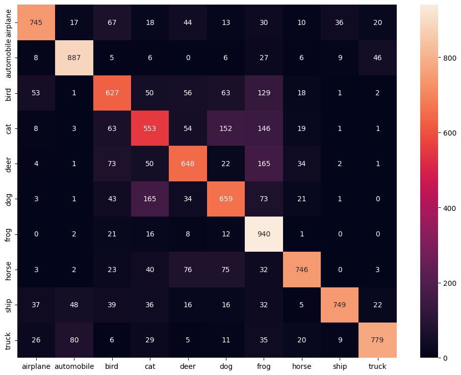

```python
# Predict the values from the validation dataset
y_pred = model_24.predict(x_test)
# Convert predictions classes to one hot vectors
y_pred_classes = np.argmax(y_pred, axis = 1)
# Convert validation observations to one hot vectors
y_true = np.argmax(y_test, axis = 1)
# Compute the confusion matrix
confusion_matrix_24 = tf.math.confusion_matrix(y_true, y_pred_classes)

#Plot results
plt.figure(figsize=(12,9))
a = sns.heatmap(confusion_matrix_24, annot = True, fmt = 'g')
a.set(xticklabels = classes, yticklabels = classes)
```

> Our model classifies frogs pretty well, with over **900** out of **1000** frog images. In addition, now we see the less scattering of red coloured pixels, and common classifications are improving slightly.

## 7. References

**[1]** https://www.kaggle.com/code/amyjang/tensorflow-cifar10-cnn-tutorial/notebook